# Introduction

Load data

```r
library(readr)
library(ggplot2)
library(dplyr)
library(tidyr)


bank_full <- read_delim("bank-full.csv", delim = ";", escape_double = FALSE, trim_ws = TRUE)
head(bank_full)
```

```
## # A tibble: 6 × 17
##     age job        marital education default balance housing loan  contact   day
##   <dbl> <chr>      <chr>   <chr>     <chr>     <dbl> <chr>   <chr> <chr>   <dbl>
## 1    58 management married tertiary  no         2143 yes     no    unknown     5
## 2    44 technician single  secondary no           29 yes     no    unknown     5
## 3    33 entrepren… married secondary no            2 yes     yes   unknown     5
## 4    47 blue-coll… married unknown   no         1506 yes     no    unknown     5
## 5    33 unknown    single  unknown   no            1 no      no    unknown     5
## 6    35 management married tertiary  no          231 yes     no    unknown     5
## # ℹ 7 more variables: month <chr>, duration <dbl>, campaign <dbl>, pdays <dbl>,
## #   previous <dbl>, poutcome <chr>, y <chr>
```

The data set consists of 16 variables describing the customer and marketing campaign along with temporal aspects: * age: Age in years * job: Occupation (qualitative variable) * marital: Marital status ( qualitative variable) * education: Highest level of education (qualitative variable) * default: has credit in default? (binary) * balance: average yearly balance * housing: has housing loan? (binary) * loan: has personal loan? (binary) * Contract: contact communication type (qualitative) * day: last contact day of the week (month) * month: last contact month of year * duration: last contact duration, in seconds * campaign: number of contacts performed during this campaign and for this client * pdays: number of days that passed by after the client was last contacted from a previous campaign (-1 means client was not previously contacted) * previous: number of contacts performed before this campaign and for this client * poutcome: outcome of the previous marketing campaign (qualitative) * y: Indicator of whether the client subscribed a term deposit (Binary target)

## Distribution

```r
library(tidyverse)
```

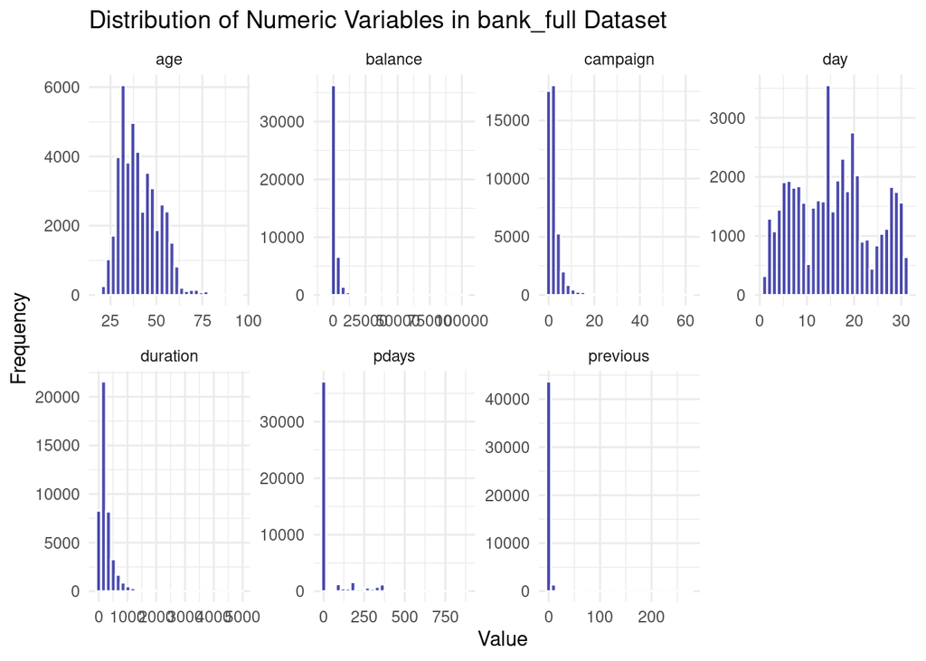

```r
library(ggplot2)

bank_long <- bank_full %>%
  select(where(is.numeric)) %>% # numeric columns
  pivot_longer(cols = everything(), names_to = "variable", values_to = "value")

ggplot(bank_long, aes(x = value)) +
  geom_histogram(bins = 30, fill = "darkblue", color = "white", alpha = 0.7) +
  facet_wrap(~ variable, scales = "free", ncol = 4) +
  labs(
    title = "Distribution of Numeric Variables in bank_full Dataset",
    x = "Value",
    y = "Frequency"
  ) +
  theme_minimal()
```

From the plots one can observe that the numeric variables are heavily skewed (balance, campaign, duration, pdays, previous). The dissemblance of the observations should take into account when considering the bias in our model fit.

```r
# Calculate and print the success rate
success_rate <- mean(bank_full$y == "yes") * 100
cat("Overall Subscription Success Rate:", round(success_rate, 2), "%\n")
```

```
## Overall Subscription Success Rate: 11.7 %
```

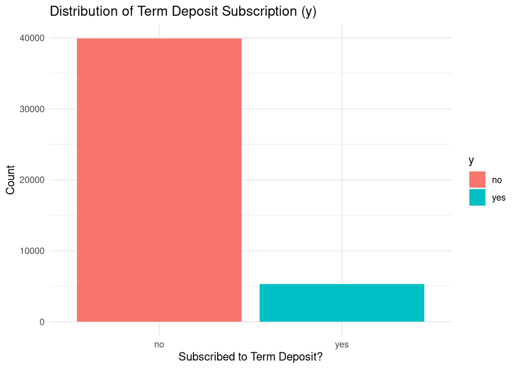

```r
# bar plot for the target variable 'y'
ggplot(bank_full, aes(x = y, fill = y)) +
  geom_bar() +
  labs(title = "Distribution of Term Deposit Subscription (y)",
       x = "Subscribed to Term Deposit?",
       y = "Count") +
  theme_minimal()
```

# Convert variables to factors for plotting

```r
bank_full$y <- as.factor(bank_full$y)
bank_full$job <- as.factor(bank_full$job)
bank_full$marital <- as.factor(bank_full$marital)
bank_full$education <- as.factor(bank_full$education)
bank_full$contact <- as.factor(bank_full$contact)
bank_full$month <- as.factor(bank_full$month)
bank_full$poutcome <- as.factor(bank_full$poutcome)
bank_full$housing <- as.factor(bank_full$housing)
bank_full$loan <- as.factor(bank_full$loan)
```

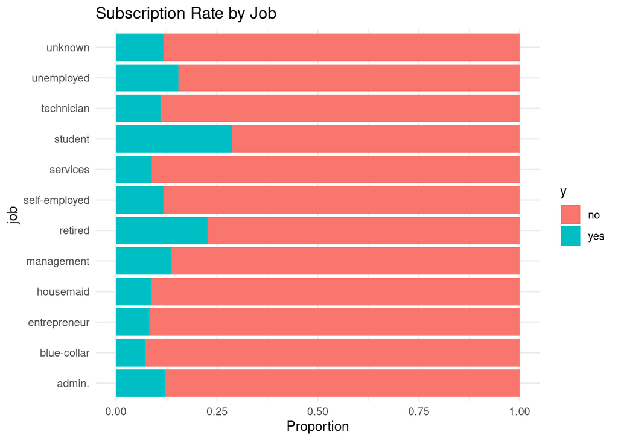

```r
ggplot(bank_full, aes(x = job, fill = y)) +
  geom_bar(position = "fill") +
  coord_flip() +
  labs(title = "Subscription Rate by Job",
       y = "Proportion") +
  theme_minimal()
```

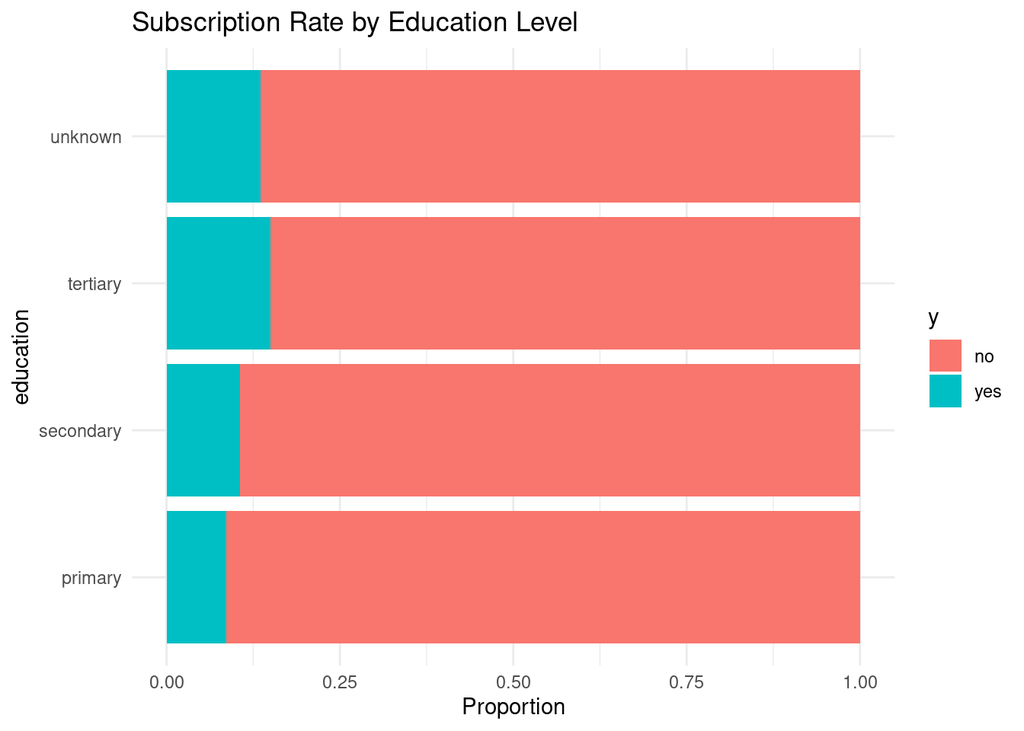

```r
ggplot(bank_full, aes(x = education, fill = y)) +
  geom_bar(position = "fill") +
  coord_flip() +
  labs(title = "Subscription Rate by Education Level",
       y = "Proportion") +
  theme_minimal()
```

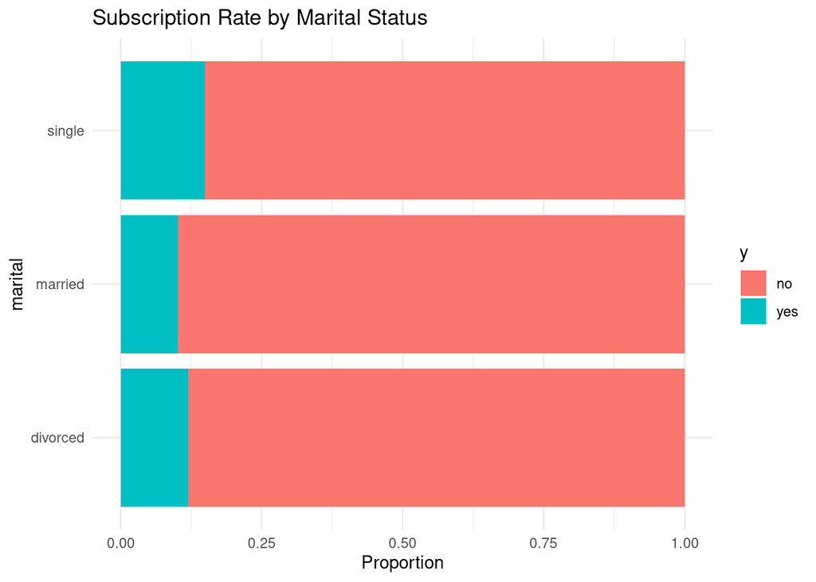

```r
ggplot(bank_full, aes(x = marital, fill = y)) +
  geom_bar(position = "fill") +
  coord_flip() +
  labs(title = "Subscription Rate by Marital Status",
       y = "Proportion") +
  theme_minimal()
```

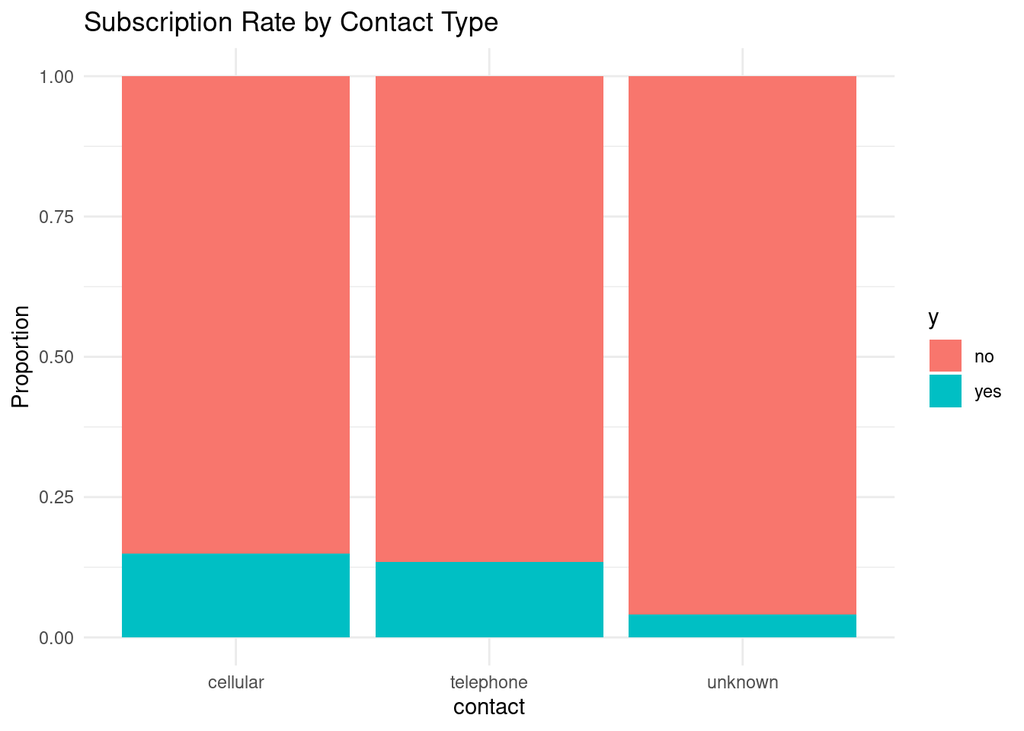

```r
ggplot(bank_full, aes(x = contact, fill = y)) +
  geom_bar(position = "fill") +
  labs(title = "Subscription Rate by Contact Type",
       y = "Proportion") +
  theme_minimal()
```

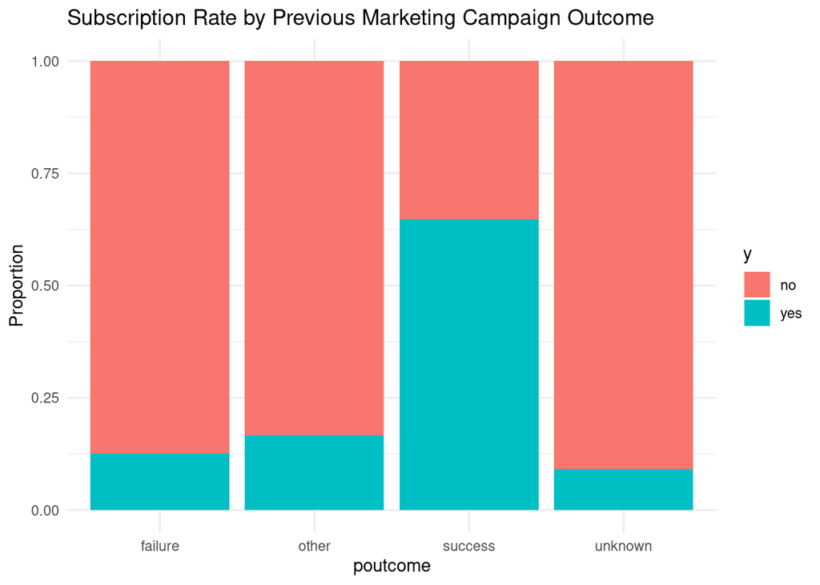

```r
ggplot(bank_full, aes(x = poutcome, fill = y)) +
  geom_bar(position = "fill") +
  labs(title = "Subscription Rate by Previous Marketing Campaign Outcome",
       y = "Proportion") +
  theme_minimal()
```

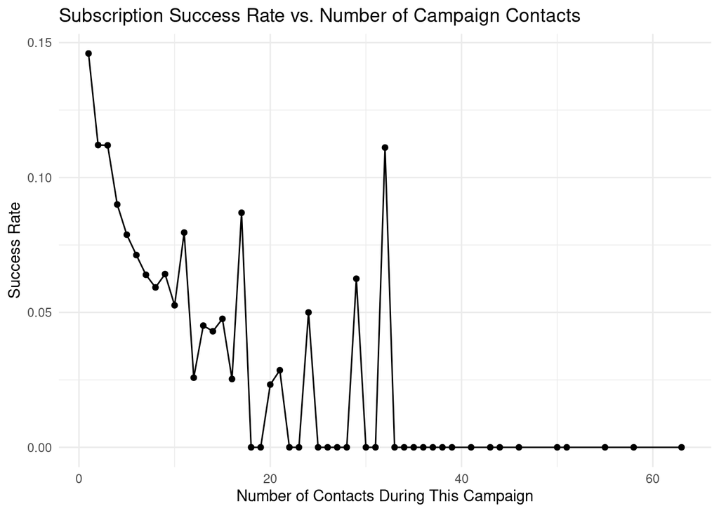

```r
bank_full %>%
  group_by(campaign) %>%
  summarise(success_rate = mean(y == "yes")) %>%
  ggplot(aes(x = campaign, y = success_rate)) +
  geom_line() +
  geom_point() +
  labs(title = "Subscription Success Rate vs. Number of Campaign Contacts",
       x = "Number of Contacts During This Campaign",
       y = "Success Rate") +
  theme_minimal()
```

```r
summary(bank_full)
```

```
##       age                 job           marital          education
##  Min.   :18.00   blue-collar:9732   divorced: 5207   primary  : 6851
##  1st Qu.:33.00   management :9458   married :27214   secondary:23202
##  Median :39.00   technician :7597   single  :12790   tertiary :13301
##  Mean   :40.94   admin.     :5171                    unknown  : 1857
##  3rd Qu.:48.00   services   :4154
##  Max.   :95.00   retired    :2264
##                  (Other)    :6835
##    default             balance       housing      loan            contact
##  Length:45211       Min.   : -8019   no :20081   no :37967   cellular :29285
##  Class :character   1st Qu.:    72   yes:25130   yes: 7244   telephone: 2906
##  Mode  :character   Median :   448                           unknown  :13020
##                     Mean   :  1362
##                     3rd Qu.:  1428
##                     Max.   :102127
##
##       day            month          duration         campaign
##  Min.   : 1.00   may    :13766   Min.   :   0.0   Min.   : 1.000
##  1st Qu.: 8.00   jul    : 6895   1st Qu.: 103.0   1st Qu.: 1.000
##  Median :16.00   aug    : 6247   Median : 180.0   Median : 2.000
##  Mean   :15.81   jun    : 5341   Mean   : 258.2   Mean   : 2.764
##  3rd Qu.:21.00   nov    : 3970   3rd Qu.: 319.0   3rd Qu.: 3.000
##  Max.   :31.00   apr    : 2932   Max.   :4918.0   Max.   :63.000
##                  (Other): 6060
##      pdays          previous           poutcome       y
##  Min.   : -1.0   Min.   :  0.0000   failure: 4901   no :39922
##  1st Qu.: -1.0   1st Qu.:  0.0000   other  : 1840   yes: 5289
##  Median : -1.0   Median :  0.0000   success: 1511
##  Mean   : 40.2   Mean   :  0.5803   unknown:36959
##  3rd Qu.: -1.0   3rd Qu.:  0.0000
##  Max.   :871.0   Max.   :275.0000
##
```

The categorical variables need to be set to categorical (or binary) variables, since R is reading the data as mere strings.

```r
bank_full$job <- as.factor(bank_full$job)
bank_full$marital <- as.factor(bank_full$marital)
bank_full$education <- as.factor(bank_full$education)
bank_full$contact <- as.factor(bank_full$contact)
bank_full$poutcome <- as.factor(bank_full$poutcome)
bank_full$day <- as.factor(bank_full$day)
bank_full$month <- as.factor(bank_full$month)

bank_full$default <- ifelse(bank_full$default == "yes", 1, 0)
bank_full$housing <- ifelse(bank_full$housing == "yes", 1, 0)
bank_full$loan <- ifelse(bank_full$loan == "yes", 1, 0)
```

## We plan to use the k-fold cross validation approach.

For consideration: Are we able to make our training sets a sort of proper stratification of our population dataset (Imbalance in amounts of customers subscribed).

```r
#bank_train <-
#bank_test <-
```

Model set up…

## Lgoistic Regression

```r
library(glmnet)
```

```r
library(ggplot2)


#bank_glm <- glm(y ~., data = bank_train, family = binomial)
#summary(bank_glm)
```

## LDA and QDA

```r
library(MASS)
#bank_lda <- lda(y ~., data = bank_full, subset = train)
#bank_lda

#bank_qda <- qda(y ~., data = bank_full, subset = train)
```

## KNN

Interpretable in a different way… Can be used to identify customers similar to those that are subscirbed.

```r
library(class)

#bank_knn <- knn()
```

Optimize K value (w.r.t cross validation test error)

## GAM

```r
library(gam)
#bank_gam <- gam(y ~ , data = bank_train) # basis functions
```

## Boosting Decision Trees

require post-hoc explanation

Potential model Mixed effects model (attribute set variables to have a random effect)